# CSC 308 Final Project - Individual Portfolio

Emmanuella Obidike

April 2026

# Project Overview

This project examines relationships between income, healthcare access, and health outcomes using county-level data. The analysis focuses on identifying patterns between economic factors and overall health rankings across selected states.

The dataset includes measures such as median household income, clinical care rankings, and health factors/outcomes indicators. The goal of the project is to understand how socioeconomic conditions influence healthcare quality and population health.

# Individual Contribution – Emmanuella Obidike

**Role:** Data Sourcing, Exploratory Data Analysis (EDA), and Interpretation

I was responsible for working with the cleaned 2021 dataset to explore relationships between income, clinical care, and health outcomes across selected states. My contribution focused on filtering the dataset, generating summary statistics, creating visualizations, and interpreting key patterns in the data.

# Dataset and Preparation

I used the cleaned dataset `Master_2021_Cleaned.csv`, which contains county-level data including:

- Median household income
- Clinical care rankings
- Health factors and health outcomes rankings
- Demographic and health-related variables

To stay consistent with the project focus, I filtered the dataset to the following states:

- Virginia
- North Carolina
- Maryland
- Georgia
- Florida

```r
# Load dataset
data21 <- read.csv("processed_data/2021/Master_2021_Cleaned.csv")

# Filter selected states
states <- c("Virginia", "North Carolina", "Maryland", "Georgia", "Florida")

filtered_data <- data21 %>%
  filter(State %in% states)
```

# Summary Statistics

```r
summary_table <- filtered_data %>%
  group_by(State) %>%
  summarise(
    avg_income = mean(Median.Household.Income, na.rm = TRUE),
    avg_clinical_rank = mean(Clinical_Care_Rank, na.rm = TRUE)
  )

summary_table
```

```
## # A tibble: 5 × 3
##   State          avg_income avg_clinical_rank
##   <chr>               <dbl>             <dbl>
## 1 Florida            55759.              29.4
## 2 Georgia            52195.              74.3
## 3 Maryland           80518.              12.5
## 4 North Carolina     52332.              49.4
## 5 Virginia           65552.              65.7
```

This provides a quick overview of differences between states.

# Visualization 1: Income vs Clinical Care

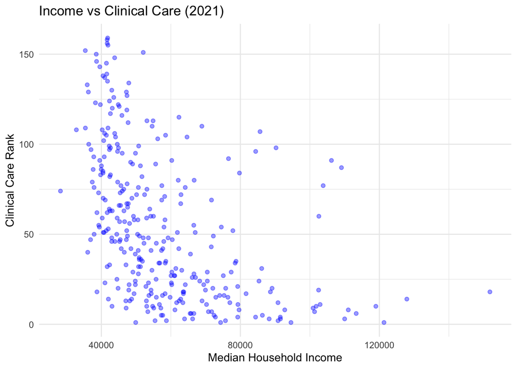

```r
ggplot(filtered_data, aes(x = Median.Household.Income, y = Clinical_Care_Rank)) +
  geom_point(color = "blue", alpha = 0.4) +
  labs(
    title = "Income vs Clinical Care (2021)",
    x = "Median Household Income",
    y = "Clinical Care Rank"
  ) +
  theme_minimal()
```

**Interpretation**

This scatter plot shows a general downward trend.  
As income increases, clinical care rank tends to improve (lower rank = better care).

# Visualization 2: Average Income by State

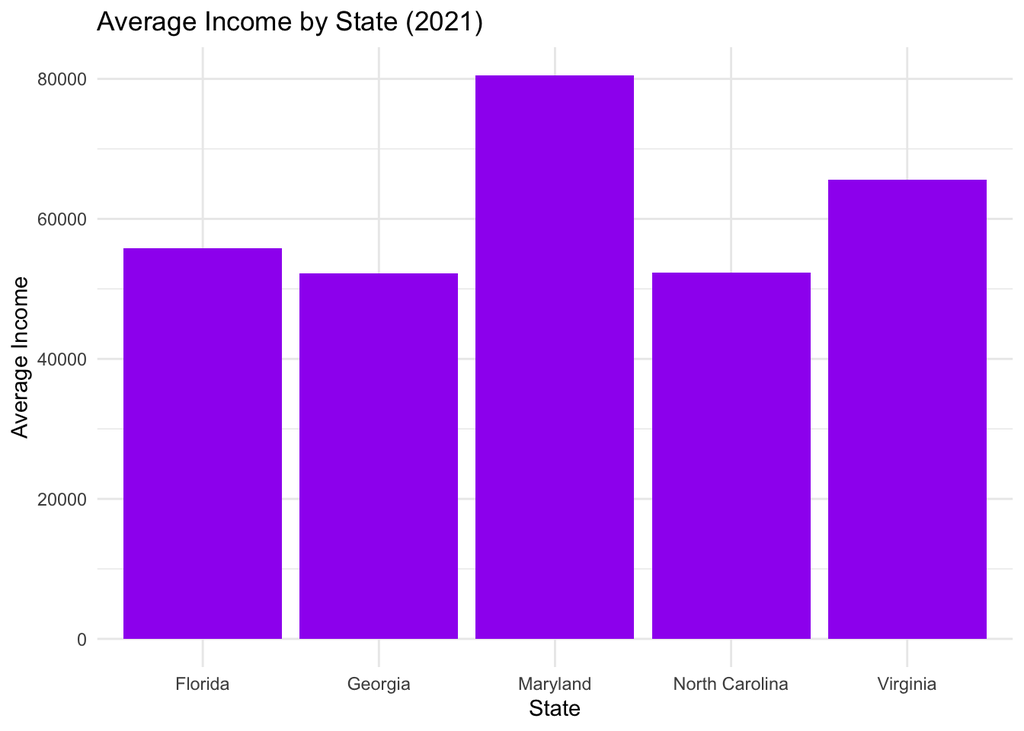

```r
ggplot(summary_table, aes(x = State, y = avg_income)) +
  geom_col(fill = "purple") +
  labs(
    title = "Average Income by State (2021)",
    x = "State",
    y = "Average Income"
  ) +
  theme_minimal()
```

**Interpretation**

Maryland has the highest average income, while Georgia and North Carolina are lower.

# Correlation: Income vs Clinical Care

```r
correlation <- cor(
  filtered_data$Median.Household.Income,
  filtered_data$Clinical_Care_Rank,
  use = "complete.obs"
)

correlation
```

```
## [1] -0.4827049
```

**Interpretation**

The correlation is about -0.48, showing a moderate negative relationship.

# Visualization 3: Health Factors vs Health Outcomes

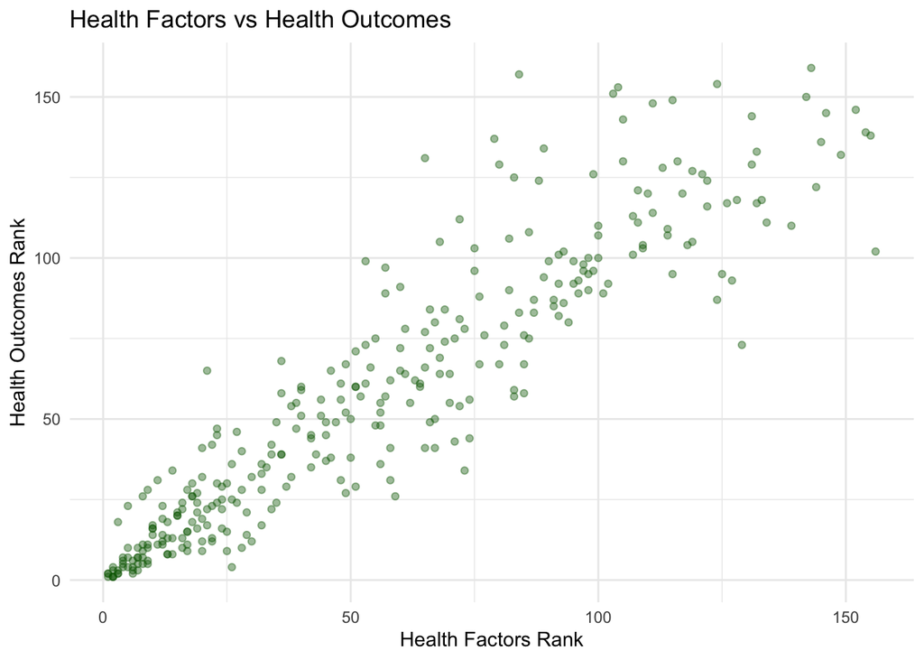

```r
ggplot(filtered_data, aes(x = Health_Factors_Rank, y = Health_Outcomes_Rank)) +
  geom_point(alpha = 0.4, color = "darkgreen") +
  labs(
    title = "Health Factors vs Health Outcomes",
    x = "Health Factors Rank",
    y = "Health Outcomes Rank"
  ) +
  theme_minimal()
```

**Interpretation**

There is a strong upward trend between health factors and outcomes.

# Correlation: Health Factors vs Outcomes

```r
correlation2 <- cor(
  filtered_data$Health_Factors_Rank,
  filtered_data$Health_Outcomes_Rank,
  use = "complete.obs"
)

correlation2
```

```
## [1] 0.9185608
```

**Interpretation**

The correlation is about 0.91, which is very strong.

# Conclusion

- Higher income is associated with improved clinical care rankings
- There are noticeable income differences across states
- Health factors strongly influence overall health outcomes

# Individual Contribution (Emmanuella Obidike)

- Loaded and filtered dataset
- Created summary tables
- Built visualizations
- Performed correlation analysis
- Interpreted results

All code in this document reflects my individual contribution.